# Trabajo Práctico Nº 3: Regresión logística

Análisis de ingresos altos en el Adult Census Income Dataset

Autor/a

Abril Weinbaur

Fecha de publicación

5 de junio de 2026

**Nota**

**Objetivo del trabajo**

Este trabajo analiza qué variables **sociodemográficas** y **laborales** se asocian con la probabilidad de tener ingresos anuales superiores a **$50.000 dólares**. Para ello, vamos a utilizar una regresión logística binomial sobre la base adult_census_USA.csv

# Preparación, carga y limpieza de datos

```r
# Instalo pacman si no está disponible.
## Lo uso para cargar todos los paquetes necesarios en una sola línea.
if (!require("pacman")) install.packages("pacman")

pacman::p_load(
  tidyverse,        # Manipulación, limpieza y visualización de datos
  here,             # Rutas relativas dentro del proyecto
  janitor,          # Limpieza de nombres de columnas
  broom,            # Ordenar resultados de modelos
  modelsummary,     # Tablas de modelos y resultados
  marginaleffects,  # Efectos marginales promedio
  scales,           # Formato de porcentajes y ejes
  kableExtra        # Formato estético de tablas
)
```

[output not shown]

## Carga de datos

```r
# Cargo la base desde la carpeta TP3/data.
# Uso here() para construir una ruta relativa desde la raíz del proyecto.
datos_raw <- read_csv(here("TP3", "data", "adult_census_USA.csv"))

# Limpio los nombres de las columnas para trabajar con nombres más cómodos en R.
datos_raw <- datos_raw |>
  clean_names()

# Reviso la estructura general de la base.
glimpse(datos_raw)
```

```
Rows: 15,766
Columns: 14
$ age            <dbl> 28, 37, 49, 52, 31, 42, 37, 30, 38, 43, 40, 35, 43, 56,…
$ workclass      <chr> "Private", "Private", "Private", "Self-emp-not-inc", "P…
$ education      <chr> "Bachelors", "Masters", "9th", "HS-grad", "Masters", "B…
$ education_num  <dbl> 13, 14, 5, 9, 14, 13, 10, 13, 7, 14, 16, 5, 7, 13, 9, 1…
$ marital_status <chr> "Married-civ-spouse", "Married-civ-spouse", "Married-sp…
$ occupation     <chr> "Prof-specialty", "Exec-managerial", "Other-service", "…
$ relationship   <chr> "Wife", "Wife", "Not-in-family", "Husband", "Not-in-fam…
$ race           <chr> "Black", "White", "Black", "White", "White", "White", "…
$ sex            <chr> "Female", "Female", "Female", "Male", "Female", "Male",…
$ capital_gain   <dbl> 0, 0, 0, 0, 14084, 5178, 0, 0, 0, 0, 0, 0, 0, 0, 0, 0, …
$ capital_loss   <dbl> 0, 0, 0, 0, 0, 0, 0, 0, 0, 0, 0, 0, 2042, 0, 0, 0, 0, 0…
$ hours_per_week <dbl> 40, 40, 16, 45, 50, 40, 80, 40, 50, 45, 60, 40, 40, 40,…
$ native_country <chr> "Cuba", "United-States", "Jamaica", "United-States", "U…
$ income         <chr> "<=50K", "<=50K", "<=50K", ">50K", ">50K", ">50K", ">50…
```

```r
# Reviso los nombres de las variables disponibles.
names(datos_raw)
```

```
 [1] "age"            "workclass"      "education"      "education_num"
 [5] "marital_status" "occupation"     "relationship"   "race"
 [9] "sex"            "capital_gain"   "capital_loss"   "hours_per_week"
[13] "native_country" "income"
```

## Limpieza inicial de la base

```r
# Creo una base de trabajo a partir de los datos originales.
# Primero elimino espacios innecesarios en las variables de texto.
datos <- datos_raw |>
  mutate(
    across(where(is.character), str_trim)
  ) |>

  # Defino income como factor.
  # El orden de los niveles es importante: <=50K queda como categoría de referencia
  # y >50K queda como la categoría cuya probabilidad vamos a modelar.
  mutate(
    income = factor(income, levels = c("<=50K", ">50K")),

    # Creo también una versión numérica de la variable dependiente.
    # Esta variable auxiliar sirve para calcular proporciones y facilitar algunos gráficos.
    income_num = if_else(income == ">50K", 1, 0)
  )

# Verifico que los niveles de income hayan quedado en el orden correcto.
levels(datos$income)
```

```
[1] "<=50K" ">50K"
```

```r
# Reviso nuevamente la estructura de la base limpia.
glimpse(datos)
```

```
Rows: 15,766
Columns: 15
$ age            <dbl> 28, 37, 49, 52, 31, 42, 37, 30, 38, 43, 40, 35, 43, 56,…
$ workclass      <chr> "Private", "Private", "Private", "Self-emp-not-inc", "P…
$ education      <chr> "Bachelors", "Masters", "9th", "HS-grad", "Masters", "B…
$ education_num  <dbl> 13, 14, 5, 9, 14, 13, 10, 13, 7, 14, 16, 5, 7, 13, 9, 1…
$ marital_status <chr> "Married-civ-spouse", "Married-civ-spouse", "Married-sp…
$ occupation     <chr> "Prof-specialty", "Exec-managerial", "Other-service", "…
$ relationship   <chr> "Wife", "Wife", "Not-in-family", "Husband", "Not-in-fam…
$ race           <chr> "Black", "White", "Black", "White", "White", "White", "…
$ sex            <chr> "Female", "Female", "Female", "Male", "Female", "Male",…
$ capital_gain   <dbl> 0, 0, 0, 0, 14084, 5178, 0, 0, 0, 0, 0, 0, 0, 0, 0, 0, …
$ capital_loss   <dbl> 0, 0, 0, 0, 0, 0, 0, 0, 0, 0, 0, 0, 2042, 0, 0, 0, 0, 0…
$ hours_per_week <dbl> 40, 40, 16, 45, 50, 40, 80, 40, 50, 45, 60, 40, 40, 40,…
$ native_country <chr> "Cuba", "United-States", "Jamaica", "United-States", "U…
$ income         <fct> <=50K, <=50K, <=50K, >50K, >50K, >50K, >50K, >50K, <=50…
$ income_num     <dbl> 0, 0, 0, 1, 1, 1, 1, 1, 0, 1, 1, 0, 0, 1, 0, 0, 0, 0, 0…
```

## Balance de la variable dependiente

```r
# Calculo la cantidad y proporción de observaciones en cada categoría de ingreso.
balance_income <- datos |>
  count(income) |>
  mutate(
    prop = n / sum(n),
    porcentaje = percent(prop, accuracy = 0.1)
  )

balance_income |>
  kable(
    col.names = c("Ingreso", "Cantidad", "Proporción", "Porcentaje"),
    caption = "Distribución de la variable dependiente"
  ) |>
  kable_styling(full_width = FALSE)
```

Distribución de la variable dependiente

| Ingreso | Cantidad | Proporción | Porcentaje |
| --- | --- | --- | --- |
| <=50K | 8258 | 0.5237854 | 52.4% |
| >50K | 7508 | 0.4762146 | 47.6% |

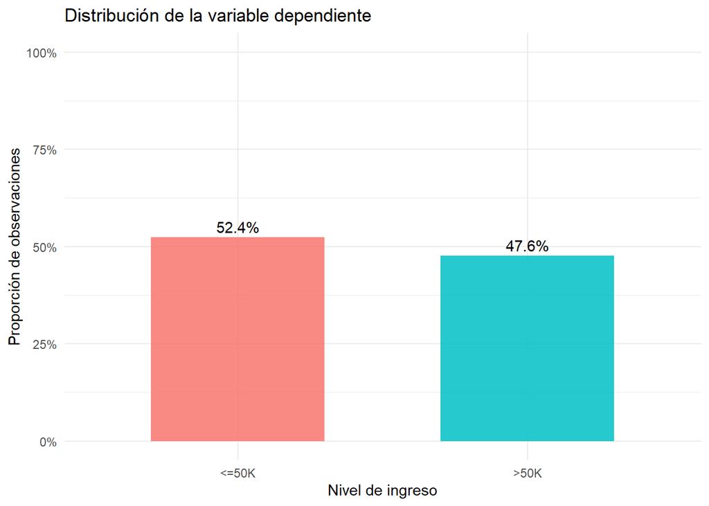

```r
# Grafico la distribución de la variable dependiente para observar el balance entre clases.
ggplot(balance_income, aes(x = income, y = prop, fill = income)) +
  geom_col(width = 0.6, alpha = 0.85) +
  geom_text(aes(label = porcentaje), vjust = -0.4) +
  scale_y_continuous(labels = percent_format(), limits = c(0, 1)) +
  labs(
    title = "Distribución de la variable dependiente",
    x = "Nivel de ingreso",
    y = "Proporción de observaciones",
    fill = "Ingreso"
  ) +
  theme_minimal() +
  theme(
    legend.position = "none"
  )
```

**Nota**

La **distribución de `income`** muestra qué proporción de la base pertenece a cada grupo de ingresos. Esta revisión es importante porque la regresión logística busca estimar la probabilidad de estar en la categoría **`>50K`**; entonces, conviene saber desde el inicio si esa categoría tiene una presencia similar a **`<=50K`** o si aparece con mucha menor frecuencia en los datos.

## Selección de variables para el análisis

```r
# Selecciono las variables que voy a usar en el análisis.
## La selección combina variables sociodemográficas y laborales que pueden estar asociadas con la probabilidad de tener ingresos superiores a 50.000 dólares anuales.
datos_modelo <- datos |>
  select(
    income,
    income_num,
    age,
    education,
    education_num,
    marital_status,
    occupation,
    relationship,
    race,
    sex,
    capital_gain,
    capital_loss,
    hours_per_week,
    native_country
  )

# Reviso si hay valores perdidos en las variables seleccionadas.
datos_modelo |>
  summarise(
    across(everything(), ~ sum(is.na(.)))
  )
```

| income | income_num | age | education | education_num | marital_status | occupation | relationship | race | sex | capital_gain | capital_loss | hours_per_week | native_country |
| --- | --- | --- | --- | --- | --- | --- | --- | --- | --- | --- | --- | --- | --- |
| 0 | 0 | 0 | 0 | 0 | 0 | 0 | 0 | 0 | 0 | 0 | 0 | 0 | 0 |

## Recodificación de variables

```r
# Reordeno variables para simplificar el análisis.
datos_modelo <- datos_modelo |>
  mutate(
    # Agrupo el estado civil en dos categorías principales.
    ## La categoría "married" reúne a personas casadas; el resto queda agrupado como "not_married".
    marital_simple = case_when(
      str_detect(marital_status, "Married") ~ "married",
      TRUE ~ "not_married"
    ),

    # Agrupo el país de origen en dos categorías.
    ## Esto permite distinguir entre personas nacidas en Estados Unidos y personas nacidas en otros países.
    native_country_simple = case_when(
      native_country == "United-States" ~ "United States",
      TRUE ~ "Other"
    ),

    # Transformo ganancias y pérdidas de capital con log1p.
    ## Uso log1p(x) porque equivale a log(x + 1), lo que evita problemas cuando el valor original es 0.
    log_capital_gain = log1p(capital_gain),
    log_capital_loss = log1p(capital_loss)
  ) |>

  # Defino explícitamente las categorías de referencia de algunas variables.
  ## Estas referencias sirven como punto de comparación en la regresión logística.
  mutate(
    sex = factor(sex),
    marital_simple = factor(marital_simple, levels = c("not_married", "married")),
    native_country_simple = factor(native_country_simple, levels = c("United States", "Other")),
    race = factor(race),
    occupation = factor(occupation),
    education = factor(education)
  )

# Reviso la estructura de la base después de las recodificaciones.
glimpse(datos_modelo)
```

```
Rows: 15,766
Columns: 18
$ income                <fct> <=50K, <=50K, <=50K, >50K, >50K, >50K, >50K, >50…
$ income_num            <dbl> 0, 0, 0, 1, 1, 1, 1, 1, 0, 1, 1, 0, 0, 1, 0, 0, …
$ age                   <dbl> 28, 37, 49, 52, 31, 42, 37, 30, 38, 43, 40, 35, …
$ education             <fct> Bachelors, Masters, 9th, HS-grad, Masters, Bache…
$ education_num         <dbl> 13, 14, 5, 9, 14, 13, 10, 13, 7, 14, 16, 5, 7, 1…
$ marital_status        <chr> "Married-civ-spouse", "Married-civ-spouse", "Mar…
$ occupation            <fct> Prof-specialty, Exec-managerial, Other-service, …
$ relationship          <chr> "Wife", "Wife", "Not-in-family", "Husband", "Not…
$ race                  <fct> Black, White, Black, White, White, White, Black,…
$ sex                   <fct> Female, Female, Female, Male, Female, Male, Male…
$ capital_gain          <dbl> 0, 0, 0, 0, 14084, 5178, 0, 0, 0, 0, 0, 0, 0, 0,…
$ capital_loss          <dbl> 0, 0, 0, 0, 0, 0, 0, 0, 0, 0, 0, 0, 2042, 0, 0, …
$ hours_per_week        <dbl> 40, 40, 16, 45, 50, 40, 80, 40, 50, 45, 60, 40, …
$ native_country        <chr> "Cuba", "United-States", "Jamaica", "United-Stat…
$ marital_simple        <fct> married, married, married, married, not_married,…
$ native_country_simple <fct> Other, United States, Other, United States, Unit…
$ log_capital_gain      <dbl> 0.000000, 0.000000, 0.000000, 0.000000, 9.552866…
$ log_capital_loss      <dbl> 0.000000, 0.000000, 0.000000, 0.000000, 0.000000…
```

**Nota**

Las **variables** seleccionadas buscan representar distintas dimensiones asociadas al nivel de ingreso: **características individuales** (edad, sexo y raza), **factores educativos** (nivel educativo alcanzado), **condiciones familiares** (estado civil), y **elementos laborales** (ocupación, horas trabajadas por semana y ganancias o pérdidas de capital). Además, fueron simplificadas algunas variables para **facilitar la interpretación del modelo**.

# Análisis exploratorio y decisiones de transformación

## Variables continuas e ingreso

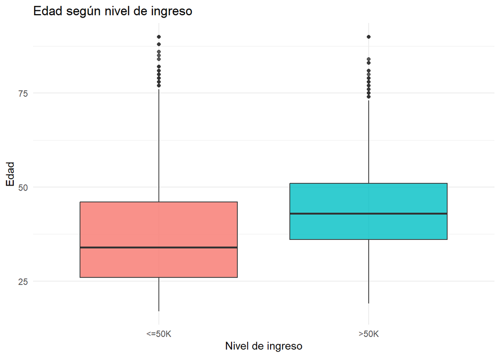

```r
# Comparo la distribución de variables continuas según el nivel de ingreso.
## Estos gráficos permiten observar si hay diferencias descriptivas entre quienes ganan <=50K y quienes ganan >50K.

ggplot(datos_modelo, aes(x = income, y = age, fill = income)) +
  geom_boxplot(alpha = 0.8) +
  labs(
    title = "Edad según nivel de ingreso",
    x = "Nivel de ingreso",
    y = "Edad",
    fill = "Ingreso"
  ) +
  theme_minimal() +
  theme(legend.position = "none")
```

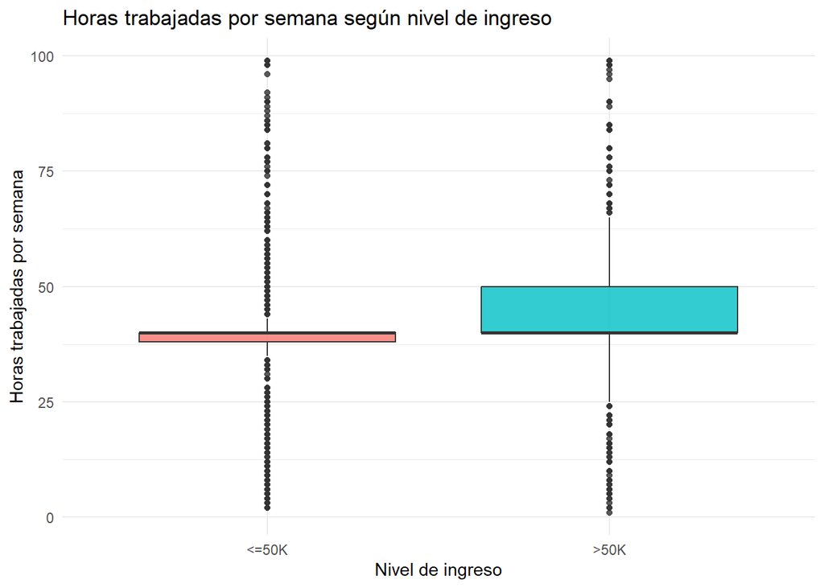

```r
ggplot(datos_modelo, aes(x = income, y = hours_per_week, fill = income)) +
  geom_boxplot(alpha = 0.8) +
  labs(
    title = "Horas trabajadas por semana según nivel de ingreso",
    x = "Nivel de ingreso",
    y = "Horas trabajadas por semana",
    fill = "Ingreso"
  ) +
  theme_minimal() +
  theme(legend.position = "none")
```

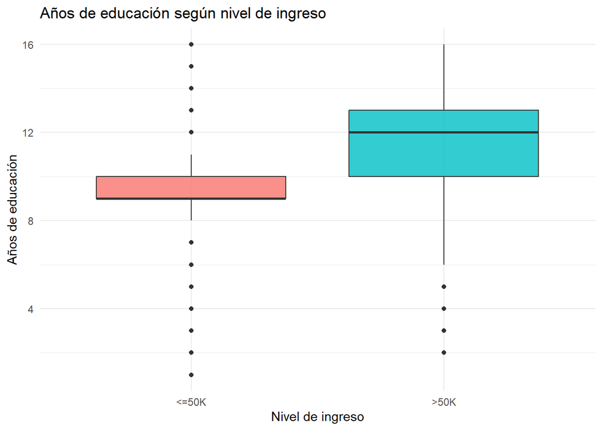

```r
ggplot(datos_modelo, aes(x = income, y = education_num, fill = income)) +
  geom_boxplot(alpha = 0.8) +
  labs(
    title = "Años de educación según nivel de ingreso",
    x = "Nivel de ingreso",
    y = "Años de educación",
    fill = "Ingreso"
  ) +
  theme_minimal() +
  theme(legend.position = "none")
```

**Nota**

Los gráficos muestran una **primera comparación entre las variables continuas y el nivel de ingreso.** La edad, las horas trabajadas por semana y los años de educación permiten observar diferencias iniciales entre ambos grupos. Aunque estas relaciones son descriptivas, nos sirven para orientar la selección de predictores antes de ajustar la regresión logística.

## Variables categóricas e ingreso

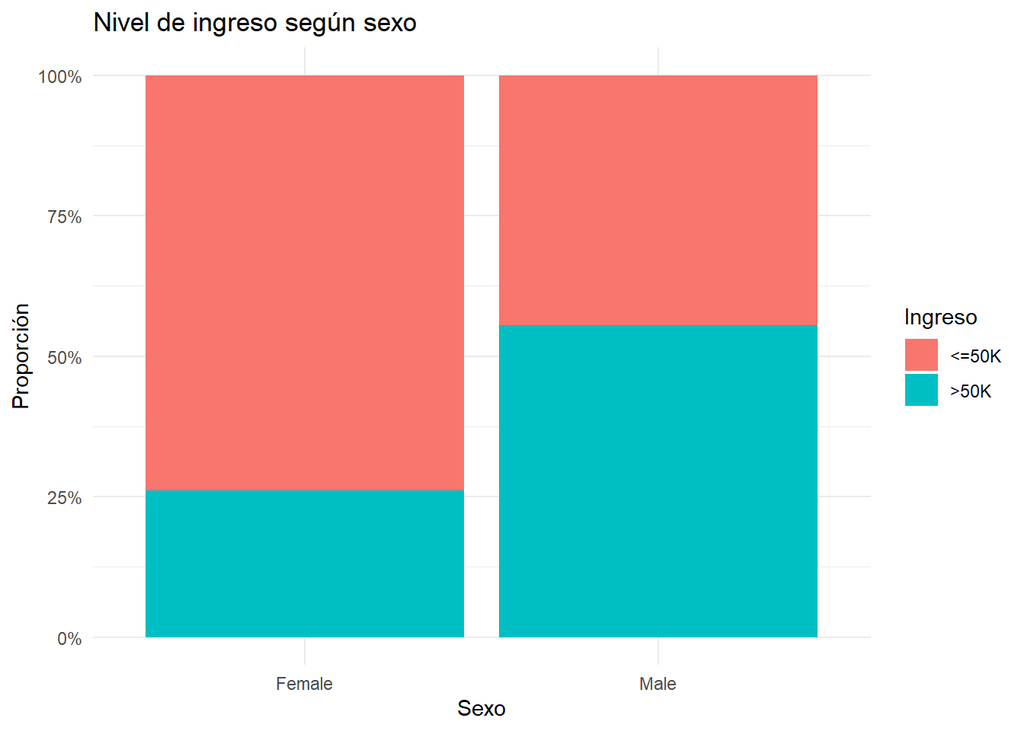

```r
# Analizo la relación entre variables categóricas y la variable de ingreso.
# Uso barras proporcionales para comparar la composición de ingresos dentro de cada categoría.

ggplot(datos_modelo, aes(x = sex, fill = income)) +
  geom_bar(position = "fill") +
  scale_y_continuous(labels = percent_format()) +
  labs(
    title = "Nivel de ingreso según sexo",
    x = "Sexo",
    y = "Proporción",
    fill = "Ingreso"
  ) +
  theme_minimal()
```

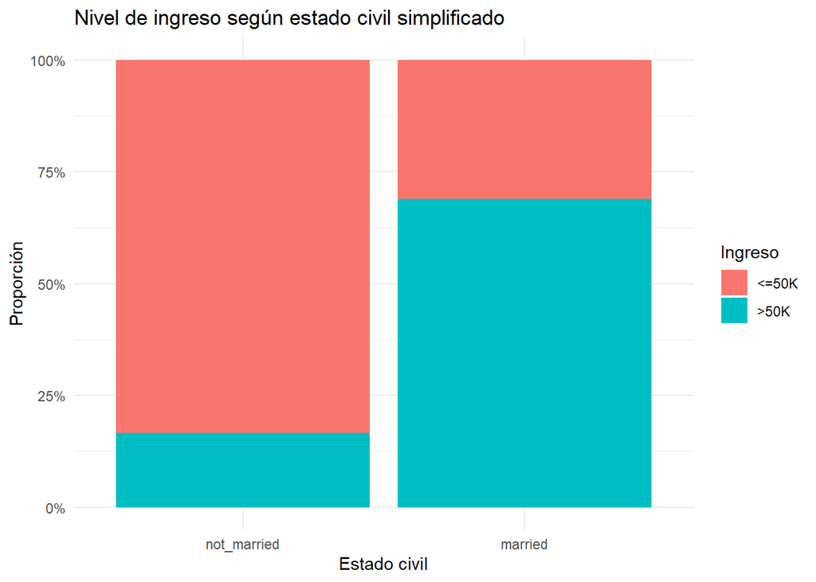

```r
ggplot(datos_modelo, aes(x = marital_simple, fill = income)) +
  geom_bar(position = "fill") +
  scale_y_continuous(labels = percent_format()) +
  labs(
    title = "Nivel de ingreso según estado civil simplificado",
    x = "Estado civil",
    y = "Proporción",
    fill = "Ingreso"
  ) +
  theme_minimal()
```

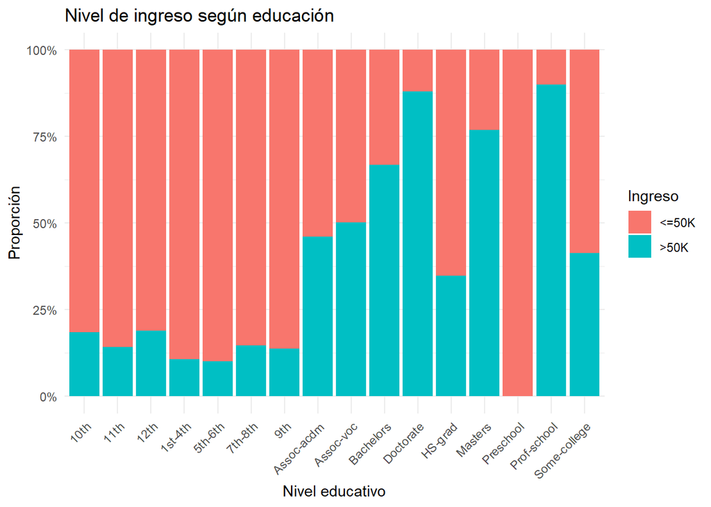

```r
ggplot(datos_modelo, aes(x = education, fill = income)) +
  geom_bar(position = "fill") +
  scale_y_continuous(labels = percent_format()) +
  labs(
    title = "Nivel de ingreso según educación",
    x = "Nivel educativo",
    y = "Proporción",
    fill = "Ingreso"
  ) +
  theme_minimal() +
  theme(
    axis.text.x = element_text(angle = 45, hjust = 1)
  )
```

**Nota**

Estos gráficos permiten comparar qué proporción de personas pertenece a cada grupo de ingresos dentro de distintas categorías. En particular, las diferencias por sexo, estado civil y nivel educativo son relevantes porque pueden mostrar patrones desiguales de inserción laboral y de acceso a ingresos altos.

## Distribución de ganancias y pérdidas de capital

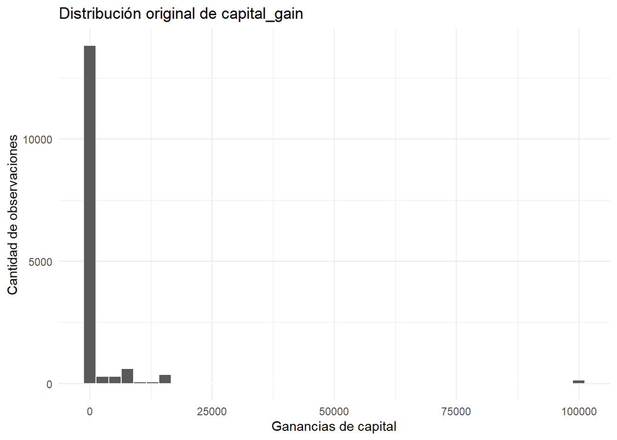

```r
# Observo la distribución original de capital_gain.
ggplot(datos_modelo, aes(x = capital_gain)) +
  geom_histogram(bins = 40, color = "white") +
  labs(
    title = "Distribución original de capital_gain",
    x = "Ganancias de capital",
    y = "Cantidad de observaciones"
  ) +
  theme_minimal()
```

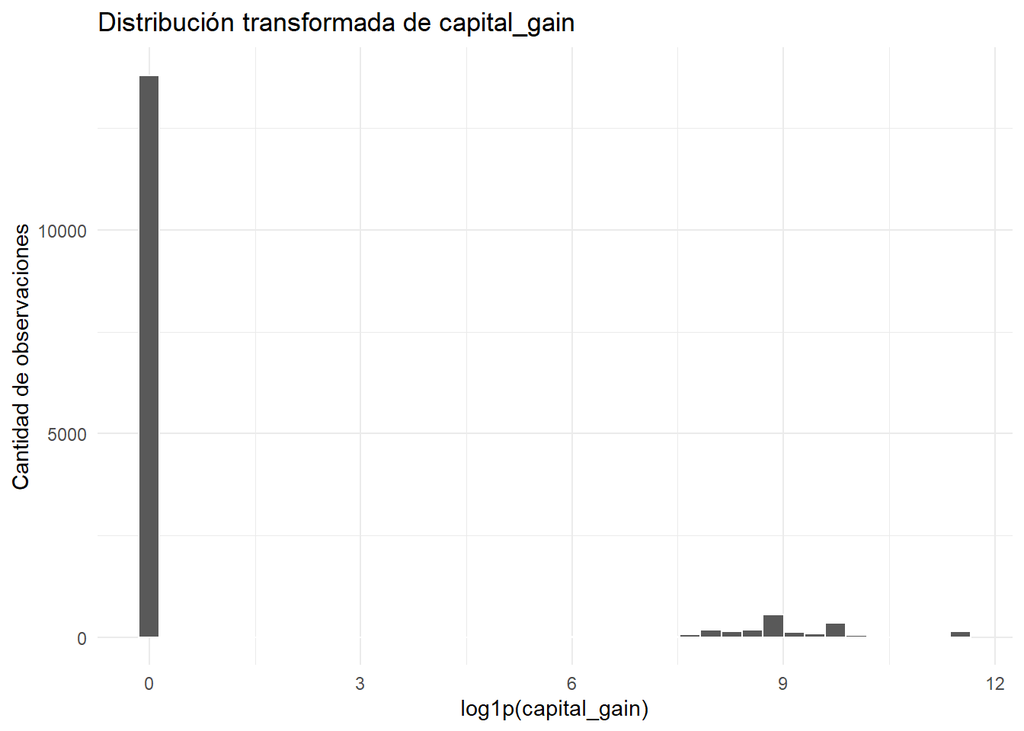

```r
# Observo la distribución transformada de capital_gain.
ggplot(datos_modelo, aes(x = log_capital_gain)) +
  geom_histogram(bins = 40, color = "white") +
  labs(
    title = "Distribución transformada de capital_gain",
    x = "log1p(capital_gain)",
    y = "Cantidad de observaciones"
  ) +
  theme_minimal()
```

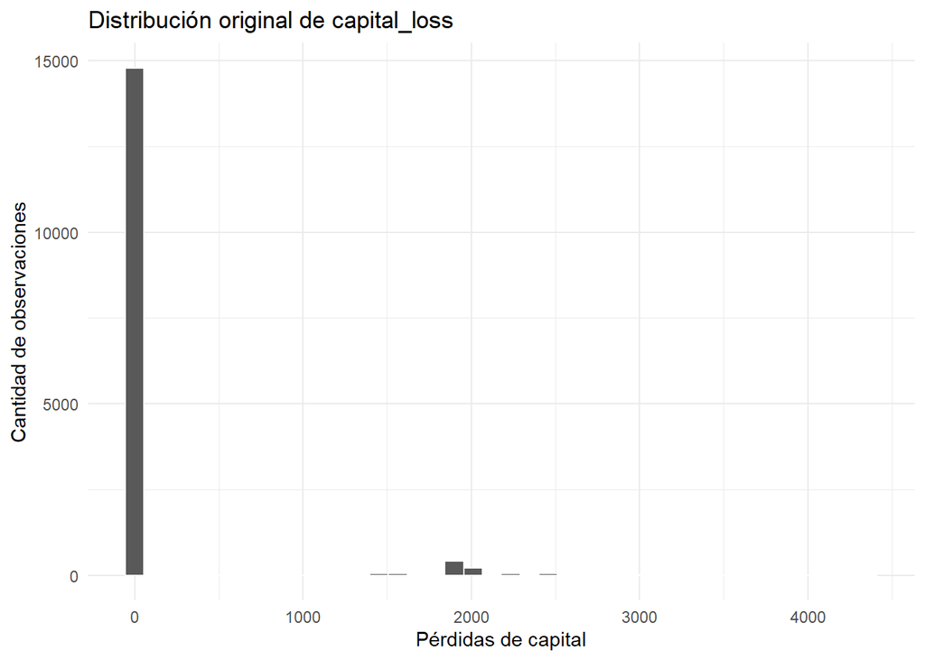

```r
# Observo la distribución original de capital_loss.
ggplot(datos_modelo, aes(x = capital_loss)) +
  geom_histogram(bins = 40, color = "white") +
  labs(
    title = "Distribución original de capital_loss",
    x = "Pérdidas de capital",
    y = "Cantidad de observaciones"
  ) +
  theme_minimal()
```

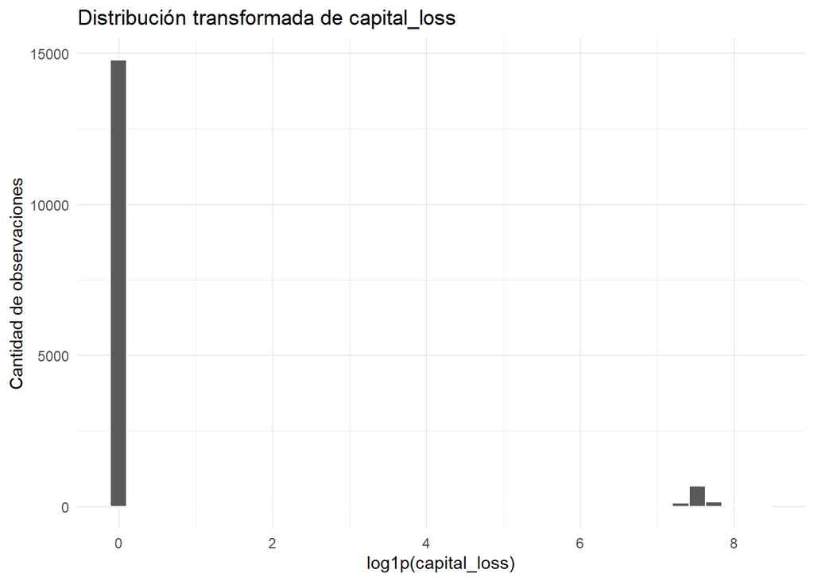

```r
# Observo la distribución transformada de capital_loss.
ggplot(datos_modelo, aes(x = log_capital_loss)) +
  geom_histogram(bins = 40, color = "white") +
  labs(
    title = "Distribución transformada de capital_loss",
    x = "log1p(capital_loss)",
    y = "Cantidad de observaciones"
  ) +
  theme_minimal()
```

**Nota**

Las variables **`capital_gain`** y **`capital_loss`** tienen una distribución muy concentrada en **valores bajos,** especialmente en cero, y algunos valores mucho más altos. Por eso se utiliza `log1p`, que equivale a calcular `log(x + 1)`. Esta transformación permite **conservar los casos con valor cero** y, al mismo tiempo, **reducir el peso visual y estadístico de los valores extremos.**

## Decisión sobre la interacción

**Nota**

A partir del análisis exploratorio, resulta razonable incorporar una interacción entre `education_num` y `sex`. La educación suele estar asociada con mejores oportunidades laborales y mayores ingresos, pero ese efecto puede no ser igual para varones y mujeres. En términos sustantivos, **la interacción permite evaluar si el aumento en la probabilidad de tener ingresos superiores a 50.000 dólares asociado a mayores años de educación cambia según el sexo de la persona.**

Por ese motivo, el primer modelo se estimará sin interacciones y el segundo incorporará el término **`education_num * sex`**. De esta manera, el modelo interactivo no solo observará el efecto general de la educación, sino también si ese efecto varía entre grupos.

# Ajuste de modelos de regresión logística

**Nota**

En esta sección se estiman **dos modelos de regresión logística** binomial. El primer modelo funciona como modelo base y no incluye interacciones. El segundo modelo incorpora la interacción entre **`education_num` y `sex`**, justificada en la sección anterior.

```r
# Ajusto el Modelo 1, sin interacciones.
## La variable dependiente es income, con <=50K como categoría de referencia y >50K como categoría cuya probabilidad se busca modelar.
modelo_1 <- glm(
  income ~ age +
    education_num +
    sex +
    marital_simple +
    race +
    hours_per_week +
    log_capital_gain +
    log_capital_loss +
    native_country_simple,
  data = datos_modelo,
  family = binomial
)

# Ajusto el Modelo 2, incorporando la interacción entre educación y sexo.
## La interacción permite evaluar si el efecto de los años de educación sobre la probabilidad de tener ingresos altos cambia según el sexo.
modelo_2 <- glm(
  income ~ age +
    education_num * sex +
    marital_simple +
    race +
    hours_per_week +
    log_capital_gain +
    log_capital_loss +
    native_country_simple,
  data = datos_modelo,
  family = binomial
)

# Reviso un resumen inicial de ambos modelos.
summary(modelo_1)
```

```
Call:
glm(formula = income ~ age + education_num + sex + marital_simple +
    race + hours_per_week + log_capital_gain + log_capital_loss +
    native_country_simple, family = binomial, data = datos_modelo)

Coefficients:
                            Estimate Std. Error z value Pr(>|z|)
(Intercept)                -9.248046   0.315495 -29.313  < 2e-16 ***
age                         0.034294   0.001889  18.153  < 2e-16 ***
education_num               0.373499   0.009929  37.618  < 2e-16 ***
sexMale                     0.203663   0.056376   3.613 0.000303 ***
marital_simplemarried       2.349690   0.052872  44.441  < 2e-16 ***
raceAsian-Pac-Islander      0.610160   0.300519   2.030 0.042321 *
raceBlack                   0.220252   0.275891   0.798 0.424678
raceOther                  -0.218348   0.423230  -0.516 0.605918
raceWhite                   0.454065   0.264701   1.715 0.086274 .
hours_per_week              0.034081   0.002116  16.109  < 2e-16 ***
log_capital_gain            0.206925   0.008762  23.615  < 2e-16 ***
log_capital_loss            0.155590   0.012813  12.143  < 2e-16 ***
native_country_simpleOther -0.309524   0.092497  -3.346 0.000819 ***
---
Signif. codes:  0 '***' 0.001 '**' 0.01 '*' 0.05 '.' 0.1 ' ' 1

(Dispersion parameter for binomial family taken to be 1)

    Null deviance: 21821  on 15765  degrees of freedom
Residual deviance: 13362  on 15753  degrees of freedom
AIC: 13388

Number of Fisher Scoring iterations: 5
```

```r
summary(modelo_2)
```

```
Call:
glm(formula = income ~ age + education_num * sex + marital_simple +
    race + hours_per_week + log_capital_gain + log_capital_loss +
    native_country_simple, family = binomial, data = datos_modelo)

Coefficients:
                            Estimate Std. Error z value Pr(>|z|)
(Intercept)                -8.997760   0.373618 -24.083  < 2e-16 ***
age                         0.034340   0.001889  18.180  < 2e-16 ***
education_num               0.350941   0.020672  16.977  < 2e-16 ***
sexMale                    -0.113009   0.261526  -0.432 0.665659
marital_simplemarried       2.348937   0.052811  44.478  < 2e-16 ***
raceAsian-Pac-Islander      0.601376   0.300382   2.002 0.045281 *
raceBlack                   0.212205   0.275665   0.770 0.441423
raceOther                  -0.221261   0.423251  -0.523 0.601137
raceWhite                   0.448310   0.264455   1.695 0.090033 .
hours_per_week              0.034229   0.002119  16.152  < 2e-16 ***
log_capital_gain            0.207080   0.008760  23.640  < 2e-16 ***
log_capital_loss            0.155912   0.012816  12.166  < 2e-16 ***
native_country_simpleOther -0.309803   0.092566  -3.347 0.000817 ***
education_num:sexMale       0.028742   0.023200   1.239 0.215394
---
Signif. codes:  0 '***' 0.001 '**' 0.01 '*' 0.05 '.' 0.1 ' ' 1

(Dispersion parameter for binomial family taken to be 1)

    Null deviance: 21821  on 15765  degrees of freedom
Residual deviance: 13361  on 15752  degrees of freedom
AIC: 13389

Number of Fisher Scoring iterations: 5
```

**Nota**

El **Modelo 1** estima la asociación entre cada predictor y la probabilidad de tener ingresos superiores a 50.000 dólares, manteniendo constantes las demás variables del modelo. El **Modelo 2** conserva los mismos predictores, pero agrega la interacción entre `education_num` y `sex`. Por lo tanto, permite observar si la relación entre educación e ingresos altos varía según el sexo de la persona.

# Interpretación de resultados y efectos marginales

**Nota**

En esta sección se trabaja con el **Modelo 2**, es decir, el modelo que incluye la interacción entre `education_num` y `sex`. Para facilitar la interpretación, primero se calculan los efectos marginales promedio y luego se presentan los odds ratios del modelo.

## Efectos marginales promedio

```r
# Calculo los efectos marginales promedio del Modelo 2.
# Los efectos marginales permiten interpretar los resultados en términos de cambios promedio
# en la probabilidad de tener ingresos superiores a 50.000 dólares.
ame_modelo_2 <- avg_slopes(modelo_2)

# Presento los efectos marginales en una tabla más clara.
ame_modelo_2 |>
  as_tibble() |>
  select(term, contrast, estimate, std.error, statistic, p.value, conf.low, conf.high) |>
  mutate(
    estimate = round(estimate, 4),
    std.error = round(std.error, 4),
    statistic = round(statistic, 3),
    p.value = round(p.value, 4),
    conf.low = round(conf.low, 4),
    conf.high = round(conf.high, 4)
  ) |>
  kable(
    col.names = c(
      "Variable",
      "Comparación",
      "AME",
      "Error estándar",
      "Estadístico",
      "p-valor",
      "IC inferior",
      "IC superior"
    ),
    caption = "Efectos marginales promedio del Modelo 2"
  ) |>
  kable_styling(full_width = FALSE)
```

Efectos marginales promedio del Modelo 2

| Variable | Comparación | AME | Error estándar | Estadístico | p-valor | IC inferior | IC superior |
| --- | --- | --- | --- | --- | --- | --- | --- |
| age | dY/dX | 0.0047 | 0.0002 | 18.848 | 0.0000 | 0.0042 | 0.0052 |
| education_num | dY/dX | 0.0510 | 0.0011 | 44.973 | 0.0000 | 0.0488 | 0.0532 |
| hours_per_week | dY/dX | 0.0047 | 0.0003 | 16.610 | 0.0000 | 0.0041 | 0.0052 |
| log_capital_gain | dY/dX | 0.0283 | 0.0011 | 25.127 | 0.0000 | 0.0261 | 0.0305 |
| log_capital_loss | dY/dX | 0.0213 | 0.0017 | 12.360 | 0.0000 | 0.0179 | 0.0247 |
| marital_simple | married - not_married | 0.3810 | 0.0078 | 49.049 | 0.0000 | 0.3658 | 0.3963 |
| native_country_simple | Other - United States | -0.0425 | 0.0127 | -3.349 | 0.0008 | -0.0673 | -0.0176 |
| race | Asian-Pac-Islander - Amer-Indian-Eskimo | 0.0826 | 0.0411 | 2.008 | 0.0446 | 0.0020 | 0.1632 |
| race | Black - Amer-Indian-Eskimo | 0.0291 | 0.0378 | 0.772 | 0.4403 | -0.0449 | 0.1031 |
| race | Other - Amer-Indian-Eskimo | -0.0301 | 0.0576 | -0.524 | 0.6005 | -0.1429 | 0.0827 |
| race | White - Amer-Indian-Eskimo | 0.0616 | 0.0362 | 1.701 | 0.0889 | -0.0094 | 0.1326 |
| sex | Male - Female | 0.0267 | 0.0080 | 3.315 | 0.0009 | 0.0109 | 0.0424 |

**Nota**

Los efectos marginales promedio muestran cuánto cambia, en promedio, la probabilidad de tener ingresos superiores a 50.000 dólares ante un cambio en cada variable, manteniendo constantes las demás variables del modelo. Esta presentación permite una lectura más directa en términos de probabilidad.

## Odds ratios del Modelo 2

```r
# Extraigo los coeficientes del Modelo 2 y los transformo a odds ratios.
## exponentiate = TRUE convierte los coeficientes logísticos en odds ratios.
odds_modelo_2 <- tidy(
  modelo_2,
  conf.int = TRUE,
  exponentiate = TRUE
) |>
  filter(term != "(Intercept)") |>
  mutate(
    term = recode(
      term,
      "age" = "Edad",
      "education_num" = "Años de educación",
      "sexMale" = "Sexo: varón",
      "marital_simplemarried" = "Estado civil: casado",
      "raceAsian-Pac-Islander" = "Raza: Asian-Pac-Islander",
      "raceBlack" = "Raza: Black",
      "raceOther" = "Raza: Other",
      "raceWhite" = "Raza: White",
      "hours_per_week" = "Horas trabajadas por semana",
      "log_capital_gain" = "Log ganancias de capital",
      "log_capital_loss" = "Log pérdidas de capital",
      "native_country_simpleOther" = "País de origen: otro",
      "education_num:sexMale" = "Educación × varón"
    )
  )

odds_modelo_2 |>
  select(term, estimate, conf.low, conf.high, p.value) |>
  mutate(
    estimate = round(estimate, 3),
    conf.low = round(conf.low, 3),
    conf.high = round(conf.high, 3),
    p.value = round(p.value, 4)
  ) |>
  kable(
    col.names = c(
      "Variable",
      "Odds ratio",
      "IC inferior 95%",
      "IC superior 95%",
      "p-valor"
    ),
    caption = "Odds ratios del Modelo 2"
  ) |>
  kable_styling(full_width = FALSE)
```

Odds ratios del Modelo 2

| Variable | Odds ratio | IC inferior 95% | IC superior 95% | p-valor |
| --- | --- | --- | --- | --- |
| Edad | 1.035 | 1.031 | 1.039 | 0.0000 |
| Años de educación | 1.420 | 1.364 | 1.480 | 0.0000 |
| Sexo: varón | 0.893 | 0.536 | 1.496 | 0.6657 |
| Estado civil: casado | 10.474 | 9.450 | 11.624 | 0.0000 |
| Raza: Asian-Pac-Islander | 1.825 | 1.018 | 3.311 | 0.0453 |
| Raza: Black | 1.236 | 0.725 | 2.140 | 0.4414 |
| Raza: Other | 0.802 | 0.345 | 1.822 | 0.6011 |
| Raza: White | 1.566 | 0.939 | 2.653 | 0.0900 |
| Horas trabajadas por semana | 1.035 | 1.031 | 1.039 | 0.0000 |
| Log ganancias de capital | 1.230 | 1.209 | 1.252 | 0.0000 |
| Log pérdidas de capital | 1.169 | 1.140 | 1.199 | 0.0000 |
| País de origen: otro | 0.734 | 0.612 | 0.879 | 0.0008 |
| Educación × varón | 1.029 | 0.983 | 1.077 | 0.2154 |

**Nota**

Los **odds ratios** permiten interpretar los coeficientes del modelo en términos de chances.

Un **valor superior a 1** indica que la variable se asocia con **mayores chances de tener ingresos superiores a 50.000 dólares.**

Un **valor inferior a 1** indica una asociación con **menores chances.**

Un **valor cercano a 1** indica que el **cambio en las chances es reducido.**

## Gráfico de bosque de odds ratios

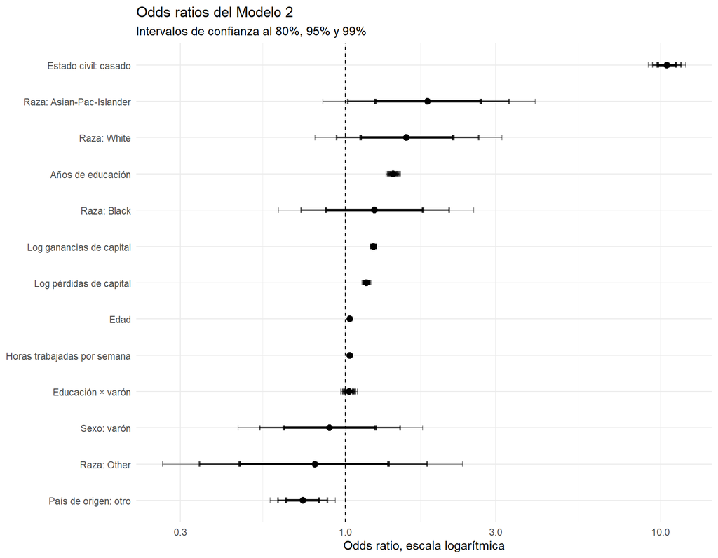

```r
# Para el forest plot calculo intervalos de confianza de 80%, 95% y 99%.
## Esto permite mostrar distintos niveles de incertidumbre alrededor de cada odds ratio.
forest_80 <- tidy(modelo_2, conf.int = TRUE, conf.level = 0.80, exponentiate = TRUE) |>
  filter(term != "(Intercept)") |>
  select(term, estimate, conf.low, conf.high) |>
  rename(conf.low.80 = conf.low, conf.high.80 = conf.high)

forest_95 <- tidy(modelo_2, conf.int = TRUE, conf.level = 0.95, exponentiate = TRUE) |>
  filter(term != "(Intercept)") |>
  select(term, conf.low, conf.high) |>
  rename(conf.low.95 = conf.low, conf.high.95 = conf.high)

forest_99 <- tidy(modelo_2, conf.int = TRUE, conf.level = 0.99, exponentiate = TRUE) |>
  filter(term != "(Intercept)") |>
  select(term, conf.low, conf.high) |>
  rename(conf.low.99 = conf.low, conf.high.99 = conf.high)

forest_data <- forest_80 |>
  left_join(forest_95, by = "term") |>
  left_join(forest_99, by = "term") |>
  mutate(
    term = recode(
      term,
      "age" = "Edad",
      "education_num" = "Años de educación",
      "sexMale" = "Sexo: varón",
      "marital_simplemarried" = "Estado civil: casado",
      "raceAsian-Pac-Islander" = "Raza: Asian-Pac-Islander",
      "raceBlack" = "Raza: Black",
      "raceOther" = "Raza: Other",
      "raceWhite" = "Raza: White",
      "hours_per_week" = "Horas trabajadas por semana",
      "log_capital_gain" = "Log ganancias de capital",
      "log_capital_loss" = "Log pérdidas de capital",
      "native_country_simpleOther" = "País de origen: otro",
      "education_num:sexMale" = "Educación × varón"
    ),
    term = fct_reorder(term, estimate)
  )

# Grafico los odds ratios con escala logarítmica.
## La línea vertical en 1 marca ausencia de cambio en las chances.
ggplot(forest_data, aes(x = estimate, y = term)) +
  geom_vline(xintercept = 1, linetype = "dashed") +
  geom_errorbarh(aes(xmin = conf.low.99, xmax = conf.high.99), height = 0.15, linewidth = 0.4, alpha = 0.45) +
  geom_errorbarh(aes(xmin = conf.low.95, xmax = conf.high.95), height = 0.15, linewidth = 0.8, alpha = 0.65) +
  geom_errorbarh(aes(xmin = conf.low.80, xmax = conf.high.80), height = 0.15, linewidth = 1.2, alpha = 0.85) +
  geom_point(size = 2.5) +
  scale_x_log10() +
  labs(
    title = "Odds ratios del Modelo 2",
    subtitle = "Intervalos de confianza al 80%, 95% y 99%",
    x = "Odds ratio, escala logarítmica",
    y = NULL
  ) +
  theme_minimal()
```

**Nota**

El **gráfico de bosque** resume visualmente la dirección y magnitud de las asociaciones estimadas por el **Modelo 2**. La **línea vertical** en 1 representa ausencia de cambio en las chances. Los **puntos ubicados a la derecha** de esa línea indican mayores chances de tener ingresos superiores a 50.000 dólares, mientras que los **puntos ubicados a la izquierda** indican menores chances. Los intervalos más anchos reflejan mayor incertidumbre en la estimación.

# Comparación global de modelos

**Nota**

En esta sección **se comparan el Modelo 1 y el Modelo 2** para evaluar si la inclusión de la interacción entre `education_num` y `sex` mejora el ajuste general. Para eso se utilizan **dos criterios:** el `AIC` y el `Pseudo R²` calculado a partir de las deviances.

```r
# Comparo ambos modelos usando métricas globales de ajuste.
## broom::glance() permite extraer indicadores generales del modelo, como AIC, deviance y null.deviance.
comparacion_modelos <- bind_rows(
  glance(modelo_1) |>
    mutate(modelo = "Modelo 1: base"),

  glance(modelo_2) |>
    mutate(modelo = "Modelo 2: interacción")
) |>
  mutate(

# Calculo el Pseudo R² visto en clase a partir de las deviances.
    pseudo_r2 = 1 - deviance / null.deviance
  ) |>
  select(
    modelo,
    AIC,
    BIC,
    deviance,
    null.deviance,
    pseudo_r2
  )

# Presento la comparación en una tabla estética.
comparacion_modelos |>
  mutate(
    AIC = round(AIC, 2),
    BIC = round(BIC, 2),
    deviance = round(deviance, 2),
    null.deviance = round(null.deviance, 2),
    pseudo_r2 = round(pseudo_r2, 4)
  ) |>
  kable(
    col.names = c(
      "Modelo",
      "AIC",
      "BIC",
      "Deviance",
      "Null deviance",
      "Pseudo R²"
    ),
    caption = "Comparación global entre modelos"
  ) |>
  kable_styling(full_width = FALSE)
```

Comparación global entre modelos

| Modelo | AIC | BIC | Deviance | Null deviance | Pseudo R² |
| --- | --- | --- | --- | --- | --- |
| Modelo 1: base | 13388.30 | 13487.95 | 13362.30 | 21820.63 | 0.3876 |
| Modelo 2: interacción | 13388.77 | 13496.09 | 13360.77 | 21820.63 | 0.3877 |

**Nota**

El AIC permite comparar modelos considerando tanto el ajuste como la complejidad: **valores más bajos indican un mejor equilibrio entre precisión y parsimonia.** El Pseudo R², calculado a partir de las deviances, permite observar **cuánto mejora el modelo respecto de un modelo nulo.** En este caso, la comparación permite evaluar si agregar la interacción entre `education_num` y `sex` aporta una **mejora sustantiva al modelo base.**

**Nota**

La comparación global muestra que **ambos modelos tienen un rendimiento muy similar**. El **Modelo 1** tiene un AIC de `13388.30` y un Pseudo R² de `0.3876`, mientras que el **Modelo 2** tiene un AIC de `13388.77` y un Pseudo R² de `0.3877`. Aunque el modelo con interacción mejora apenas el Pseudo R², **esa diferencia es prácticamente nula**. Además, el AIC aumenta levemente, lo que indica que la **mayor complejidad del Modelo 2 no se traduce en una mejora clara del ajuste.**

Por lo tanto, **la interacción entre `education_num` y `sex` no parece mejorar sustantivamente el modelo**. En términos prácticos, el Modelo 1 resulta más conveniente porque alcanza un ajuste casi idéntico sin agregar el término interactivo.

# Conclusión final

**Nota**

En este trabajo se estimaron modelos de regresión logística binomial para analizar **qué variables sociodemográficas y laborales se asocian con la probabilidad de tener ingresos anuales superiores a 50.000 dólares.**

El análisis exploratorio mostró **diferencias relevantes entre los grupos de ingreso según edad, educación, horas trabajadas, sexo, estado civil y capital acumulado**. Además, las variables `capital_gain` y `capital_loss` presentaban una fuerte concentración en valores bajos y varios valores extremos, por lo que fueron transformadas mediante `log1p`.

En términos del modelo, los resultados muestran que **variables como los años de educación, el estado civil, las horas trabajadas por semana y las ganancias de capital están asociadas con mayores chances de pertenecer al grupo de ingresos superiores a 50.000 dólares.** A su vez, el análisis mediante efectos marginales permitió interpretar estos resultados en términos de cambios promedio en la probabilidad, lo que facilita una lectura más directa que los coeficientes logísticos originales.

La comparación entre modelos indica que **la interacción entre `education_num` y `sex` no mejora sustantivamente el ajuste.** El Modelo 2 presenta un Pseudo R² apenas superior al del Modelo 1, pero también un AIC levemente mayor. Por eso, el Modelo 1 resulta más simple y alcanza un ajuste prácticamente equivalente sin incorporar el término interactivo.